# Activity: Street or Road?

Nandagopal Panicker

## Load in the data

```r
#load libraries
library(tidyverse)
#load in the data here
# we will only be using the "street-addresses.csv" file from the text
voters_file <- "C:\\Users\\nanda\\STAT 184 Summer\\Datasets\\street-addresses.csv"
medicare_file <- "C:\\Users\\nanda\\STAT 184 Summer\\Datasets\\CMS_ProvidersSimple.rds"
voters <- read.csv(voters_file)
medicare <- readRDS(medicare_file)
```

```r
head(voters$address, 20)
```

```
 [1] "2117 MARINER CIRCLE" "101 EPPING WAY"      "PO BOX 58592"        "5102 ECHO RIDGE RD"
 [5] "PO BOX 37218"        "PO BOX 37218"        "PO BOX 1953"         "PO BOX 132"
 [9] "PO BOX 360"          "5007 PURITAN RD"     "PO BOX 118"          "PO BOX 1462"
[13] "PO BOX 603"          "04-I ROBIN CIRCLE"   "PO BOX 1348"         "4800 WESTERN BLVD"
[17] "NCSU B0X 15637"      "NCSU BOX 15099"      "NCSU BOX 15530"      "NCSU BOX 04283"
```

```r
head(medicare$address, 20)
```

```
 [1] "900 SETON DR"               "2650 RIDGE AVE"             "4126 N HOLLAND SYLVANIA RD"
 [4] "456 MAGEE AVE"              "11100 EUCLID AVE"           "12605 E 16TH AVE"
 [7] "1565 SAXON BLVD STE 202"    "1021 PARK AVE"              "11035 E RICHFIELD RD"
[10] "800 BUFFALO ST"             "1867 E FIR AVE STE 104"     "4410 W 16TH AVE"
[13] "7401 S. MAIN"               "501 N GRAHAM ST"            "2215 PORTLAND AVE"
[16] "8 RICHLAND MEDICAL PARK DR" "5471 LA PALMA AVE"          "3815 N VERMILION ST"
[19] "2930 11TH AVE"              "515 N MAIN ST"
```

## Recreate Solved Example using `sample(50)`

```r
Sample <- voters %>% sample_n(size = 50)
Matches_PO <- Sample %>% filter(str_detect(address, "PO"))
print(Matches_PO$address)
```

```
 [1] "PO BOX 37512" "PO BOX 0888"  "PO BOX 723"   "PO BOX 1704"  "PO BOX 98783" "PO BOX 31014"
 [7] "PO BOX 1265"  "PO BOX 37297" "PO BOX 1021"  "PO BOX 493"   "PO BOX 1962"  "PO BOX 136"
[13] "PO BOX 774"   "PO BOX 353"   "PO BOX 533"   "PO BOX 1037"  "PO BOX 555"   "PO BOX 1090"
[19] "PO BOX 3354"  "PO BOX 12183" "PO BOX 1103"  "PO BOX 791"   "PO BOX 24846" "PO BOX 40032"
[25] "PO BOX 37232" "PO BOX 650"   "PO BOX 1704"  "PO BOX 1301"
```

```r
Dont_PO <- Sample %>% filter(!str_detect(address, "PO"))
print(Dont_PO$address)
```

```
 [1] "5600 ROCK SERVICE STATION RD" "1112 PULLEN HALL BOX 7315"    "NCSU BOX 15608"
 [4] "BOX 7315"                     "108 S SHETLAND CT"            "P O BOX 1671"
 [7] "4512-306 BAYMAR DR"           "3612 KAPALUA WAY"             "321 BEAR CREEK PATH"
[10] "NCSU BOX 22360"               "2784-1 CLINELAND ROAD"        "7041 INDIAN WELLS RD"
[13] "8116 S TRYON ST B-3 256"      "2352 SILAS CREEK PKWY"        "220 SNOW AVE"
[16] "401 PARKTON CT APT I"         "1000 N MAIN ST"               "NCSU BOX 03217"
[19] "2120 LARSON DR APT 101"       "2474 WALNUT ST"               "4705 SHADOW RIDGE COURT"
[22] "SEBTS BOX BO-15-A"
```

```r
pattern <- "BOX\\s+(\\d+)"
Matches_BOX <- Sample %>% filter(str_detect(address, pattern))
print(Matches_BOX$address)
```

```
 [1] "PO BOX 37512"              "PO BOX 0888"               "1112 PULLEN HALL BOX 7315"
 [4] "PO BOX 723"                "NCSU BOX 15608"            "BOX 7315"
 [7] "PO BOX 1704"               "PO BOX 98783"              "PO BOX 31014"
[10] "PO BOX 1265"               "PO BOX 37297"              "PO BOX 1021"
[13] "P O BOX 1671"              "PO BOX 493"                "PO BOX 1962"
[16] "PO BOX 136"                "NCSU BOX 22360"            "PO BOX 774"
[19] "PO BOX 353"                "PO BOX 533"                "PO BOX 1037"
[22] "PO BOX 555"                "PO BOX 1090"               "PO BOX 3354"
[25] "PO BOX 12183"              "PO BOX 1103"               "PO BOX 791"
[28] "PO BOX 24846"              "PO BOX 40032"              "PO BOX 37232"
[31] "PO BOX 650"                "PO BOX 1704"               "NCSU BOX 03217"
[34] "PO BOX 1301"
```

```r
Dont_BOX <- Sample %>% filter(!str_detect(address, pattern))
print(Dont_BOX)
```

| address |
| --- |
| 5600 ROCK SERVICE STATION RD |
| 108 S SHETLAND CT |
| 4512-306 BAYMAR DR |
| 3612 KAPALUA WAY |
| 321 BEAR CREEK PATH |
| 2784-1 CLINELAND ROAD |
| 7041 INDIAN WELLS RD |
| 8116 S TRYON ST B-3 256 |
| 2352 SILAS CREEK PKWY |
| 220 SNOW AVE |

[output cut: 6 more lines]

```r
BoxNumbers <- Matches_BOX %>%
  extract(address, into = "boxnum", regex = pattern)

print(BoxNumbers$boxnum)
```

```
 [1] "37512" "0888"  "7315"  "723"   "15608" "7315"  "1704"  "98783" "31014" "1265"  "37297"
[12] "1021"  "1671"  "493"   "1962"  "136"   "22360" "774"   "353"   "533"   "1037"  "555"
[23] "1090"  "3354"  "12183" "1103"  "791"   "24846" "40032" "37232" "650"   "1704"  "03217"
[34] "1301"
```

## Recreate Soved Example using the entire `Address` data set

Note: I have named the dataset voters instead of address.

```r
Matches_PO <- voters %>% filter(str_detect(address, "PO"))
Dont_PO <- voters %>% filter(!str_detect(address, "PO"))
pattern <- "BOX\\s+(\\d+)"
Matches_BOX <- voters %>% filter(str_detect(address, pattern))
Dont_BOX <- voters %>% filter(!str_detect(address, pattern))
```

```r
print(Dont_PO)
```

| address |
| --- |
| 2117 MARINER CIRCLE |
| 101 EPPING WAY |
| 5102 ECHO RIDGE RD |
| 5007 PURITAN RD |
| 04-I ROBIN CIRCLE |
| 4800 WESTERN BLVD |
| NCSU B0X 15637 |
| NCSU BOX 15099 |
| NCSU BOX 15530 |
| NCSU BOX 04283 |

[output cut: 990 more lines]

```r
print(Dont_BOX)
```

| address |
| --- |
| 2117 MARINER CIRCLE |
| 101 EPPING WAY |
| 5102 ECHO RIDGE RD |
| 5007 PURITAN RD |
| 04-I ROBIN CIRCLE |
| 4800 WESTERN BLVD |
| NCSU B0X 15637 |
| 2801 NELLOWOOD ST |
| 237 LARCHMONT ROAD |
| 2114 ORCHARD CT |

[output cut: 990 more lines]

```r
BoxNumbers <- Matches_BOX %>%
  extract(address, into = "boxnum", regex = pattern)
print(BoxNumbers$boxnum)
```

```
   [1] "58592"  "37218"  "37218"  "1953"   "132"    "360"    "118"    "1462"   "603"    "1348"
  [11] "15099"  "15530"  "04283"  "4133"   "18285"  "5006"   "276"    "5681"   "1023"   "1723"
  [21] "15149"  "33082"  "21146"  "22339"  "99832"  "69"     "1037"   "91645"  "887"    "40065"
  [31] "31851"  "15807"  "04630"  "15357"  "562"    "70"     "70"     "1651"   "4008"   "15603"
  [41] "16146"  "15891"  "60"     "423"    "22773"  "271"    "30951"  "7315"   "4003"   "65"
  [51] "2153"   "1642"   "04067"  "15300"  "22179"  "15107"  "21532"  "15123"  "824"    "14881"
  [61] "14881"  "16217"  "22829"  "16054"  "653"    "22104"  "70"     "70"     "31752"  "1131"
  [71] "21207"  "97996"  "4905"   "2031"   "21638"  "628"    "71443"  "1093"   "790"    "1054"
  [81] "1098"   "3023"   "5372"   "496"    "441"    "99567"  "13"     "1403"   "40"     "1804"
  [91] "33254"  "171"    "67"     "16110"  "21146"  "15072"  "14185"  "490"    "21192"  "511"
 [101] "21476"  "03255"  "41672"  "370"    "90294"  "932"    "1004"   "27111"  "1249"   "581"
 [111] "27092"  "10551"  "98478"  "112"    "5201"   "16366"  "981"    "981"    "12191"  "37236"
 [121] "99064"  "21389"  "2583"   "144"    "1213"   "37022"  "12783"  "582"    "1822"   "2152"
 [131] "2152"   "90333"  "1190"   "98628"  "553"    "40183"  "41274"  "91161"  "1687"   "58134"
 [141] "453"    "1027"   "1687"   "504"    "98482"  "21212"  "191"    "115"    "37456"  "415"
```

[output cut: 86 more lines]

#### Additional Question: How many addresses are a PO BOX (including NCSU BOX)?

```r
pattern_PO_BOX <- "PO\\s+BOX|NCSU\\s+BOX"
Matches_PO_BOX <- voters %>% filter(str_detect(address, pattern_PO_BOX))
num_PO_BOX <- nrow(Matches_PO_BOX)
num_PO_BOX
```

```
[1] 10593
```

My answer here……

The number of PO Box addresses including NCSU are 10593.

## Back to the Streets: Your Turn

#### Part 1: Explain (in english) each line of the following code chunk

```r
pattern <- "(ST|RD|ROAD)"
LeftOvers <-
  Addresses %>%
  filter( !grepl(pattern, address),
          !grepl("\\sAPT|UNIT\\s[\\d]+$", address),
          !grepl(" BOX ", address)
          )
```

My answer here…….

The code starts by defining a regex pattern to match street abbreviations like “ST”, “RD”, or “ROAD”. It then filters the Addresses dataset, creating a new variable LeftOvers. The filter() function excludes rows where the address contains any of the specified abbreviations, apartment or unit designations (like “APT” or “UNIT” followed by digits), or the term “BOX” surrounded by spaces. This results in LeftOvers containing addresses that do not have any of these patterns.

#### Part 2: Implement your method on the entire `Addresses` data set. Explain how your code works line by line.

```r
pattern <- "(ST|RD|ROAD)"

LeftOvers <-
  voters %>%
  filter(
    !grepl(pattern, address),
    !grepl("\\sAPT|UNIT\\s[\\d]+$", address),
    !grepl(" BOX ", address)
  )

LeftOvers
```

| address |
| --- |
| 2117 MARINER CIRCLE |
| 101 EPPING WAY |
| 04-I ROBIN CIRCLE |
| NCSU B0X 15637 |
| 4719 BROWN TRAIL |
| 130 THE WINERY |
| 5250 ADAMS AVE |
| 7416 IVY LEAGUE LN |
| 12629 WATERMAN DR |
| HMIA-267 |

[output cut: 990 more lines]

My answer here…….

The code starts by defining a regex pattern to match common street abbreviations like “ST”, “RD”, or “ROAD”. It then filters the voters dataset, creating a new variable LeftOvers. The filter() function is used to exclude rows where the address contains any of these abbreviations, as well as those with apartment or unit designations (“APT” or “UNIT” followed by digits at the end), and addresses that include the term “BOX” surrounded by spaces. The resulting LeftOvers dataset contains addresses that do not match these excluded patterns.

#### Additional Question 1: Present your result from part 2 by providing a table in descending order of popularity for the street name endings you found

| ending | n |
| --- | --- |
| RD | 603 |
| ST | 359 |
| ROAD | 183 |

#### Additional Question 2: Present your result by using ggplot to a bar chart in descending order of popularity for the street name endings you found previously.

Note: make sure your order street names according to popularity, not alphabetically.

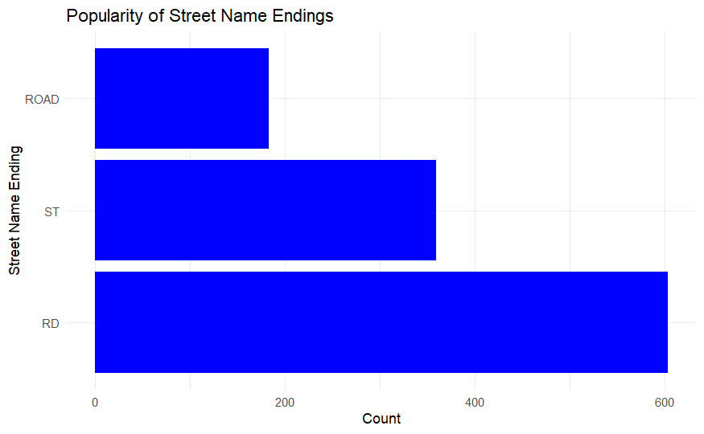

```r
ggplot(StreetEndings_sorted, aes(x = reorder(ending, -n), y = n)) +
  geom_bar(stat = "identity", fill = "blue") +
  labs(x = "Street Name Ending", y = "Count", title = "Popularity of Street Name Endings") +
  theme_minimal() +
  coord_flip()
```

#### Additional Question 3: Comment on any patterns you see

My answer here…….

- RD is the most popular Street Name Ending with roughly 600 or so appearances
- Second Being ST with more than 300 occurences but less than 400, we can estimate it to be around 350.
- Lastly, the least popular street name ending is Road, with just below 200 appearances.